# assignment1

### Read data

Loading

```r
dat <- read.csv("activity.csv")
```

and building summary of steps per day

```r
dd <- dat %>% group_by(date) %>% summarise(ds = sum(steps, na.rm = TRUE))
```

### Historgram and mean total number of steps

Histogram

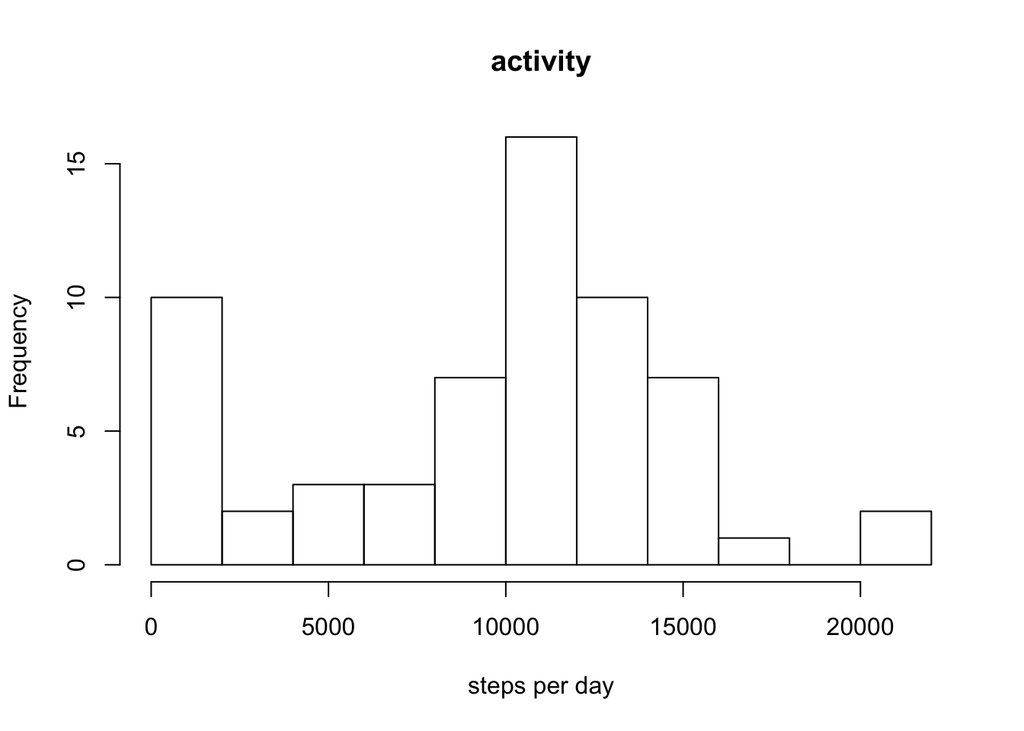

```r
hist(dd$ds, breaks=10, xlab = "steps per day", main="activity")
```

and median, mean

```r
ave <- as.integer(round(mean(dd$ds, na.rm = TRUE), 0))
med <- median(dd$ds, na.rm = TRUE)
```

Mean number of daily steps are 9354, and median daily steps are 10395

### Daily activity pattern

5-minute interval, on average across all the days in the dataset, containing the maximum number of steps:

```r
di <- dat %>% group_by(interval) %>% summarise(ave = mean(steps, na.rm = TRUE))
ii <- di$interval[which.max(di$ave)]
sm <- round(max(di$ave),0)
```

Interval number 835 is the one with the most average steps over all days (206 steps)

Plotting time series of activity

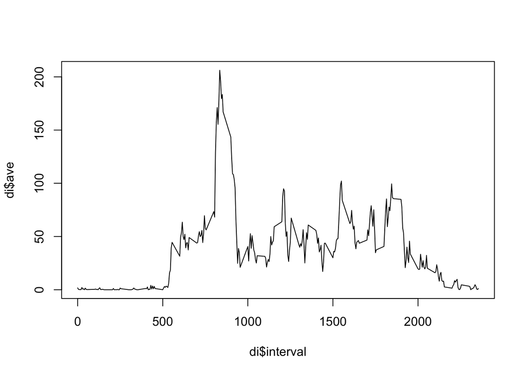

```r
plot(di$interval, di$ave, type="l")
```

### Imputing missing values

Number of missing values:

```r
vm <- is.na(dat$steps)
vl <- length(vm)    # number of data records
vs <- sum(vm)       # number of records with missing steps
vr <- round(100 * vs / vl, 0)       # missing values in %
```

Out of a total of 17568 records, 2304 are missing, so a ratio of 13%

Devise a strategy for filling in all of the missing values in the dataset. The strategy does not need to be sophisticated. Good, it is late and I am tired. Replacing NA with mean.

```r
d2 <- dat
d2$steps[vm] <- round(mean(dat$steps, na.rm = TRUE), 0)
```

and building summary of steps per day

```r
dd <- d2 %>% group_by(date) %>% summarise(ds = sum(steps, na.rm = TRUE))
```

and histogram

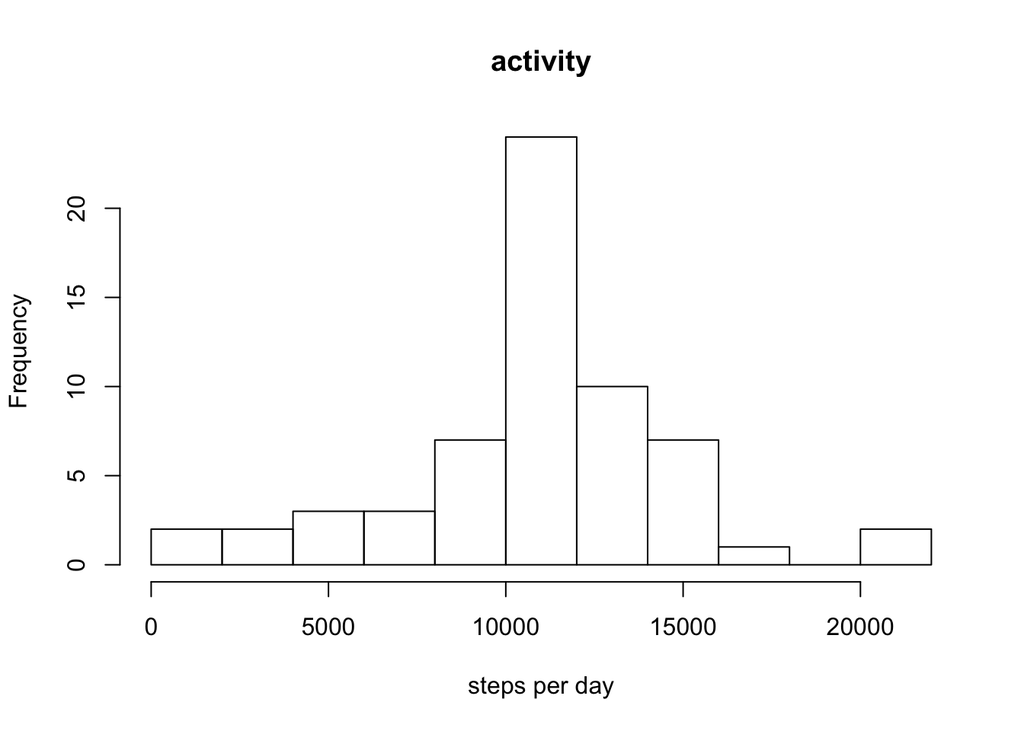

```r
hist(dd$ds, breaks=10, xlab = "steps per day", main="activity")
```

and median, mean

```r
ave2 <- as.integer(round(mean(dd$ds, na.rm = TRUE), 0))
med2 <- as.integer(median(dd$ds, na.rm = TRUE))

# percent difference old to new ratio
1-ave/ave2
```

```
## [1] 0.1300223
```

```r
# and as a reminder, ratio of missing values
print(vr/100)
```

```
## [1] 0.13
```

New, after imputation, mean number of daily steps are 10752, and median daily steps are 10656.

### Weekdays and weekends

converting to real dates and generate weekday, weekend factor

```r
dates <- strptime(d2$date, format="%Y-%m-%d")
wdays <- weekdays(dates)
we <- wdays %in% c("Saturday",  "Sunday")
d2$ww <- factor(we, labels = c("weekday", "weekend"))
```

5-minute interval, on average across all the days but separating out weekends from weekdays:

```r
di <- d2 %>% group_by(ww, interval) %>% summarise(ave = mean(steps, na.rm = TRUE))
```

and plotting the time series of the activities

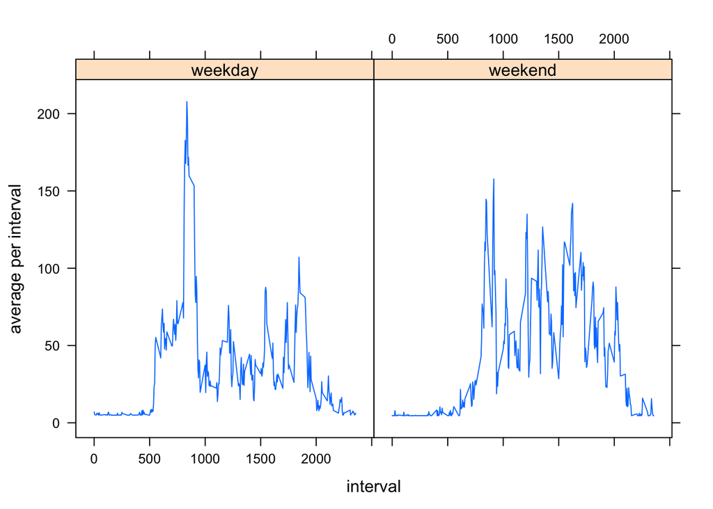

```r
library(lattice)
xyplot( ave ~ interval  | ww, data = di, type = "l", ylab="average per interval")
```